# Análise da Bay Area Bike Share

## Introdução

> **Dica**: Seções citadas como esta fornecerão instruções úteis sobre como navegar e usar um notebook do iPython.

[Bay Area Bike Share](http://www.bayareabikeshare.com/) é uma empresa que oferece aluguel de bicicletas on-demand para clientes em San Francisco, Redwood City, Palo Alto, Mountain View e San Jose. Os usuários podem desbloquear bicicletas de uma variedade de estações em cada cidade, e devolvê-las em qualquer estação dentro da mesma cidade. Os usuários pagam o serviço por meio de assinatura anual ou pela compra de passes de 3 dias ou 24 horas. Os usuários podem fazer um número ilimitado de viagens. Viagens com menos de trinta minutos de duração não têm custo adicional; Viagens mais longas incorrem em taxas de horas extras.

Neste projeto, você vai se colocar no lugar de um analista de dados realizando uma análise exploratória sobre os dados. Você vai dar uma olhada em duas das principais partes do processo de análise de dados: limpeza de dados e análise exploratória. Mas antes que você comece a olhar os dados, pense algumas perguntas que você pode querer fazer sobre os dados. Considere, por exemplo, se você estivesse trabalhando para Bay Area Bike Share: que tipo de informação você gostaria de saber a fim de tomar decisões de negócios mais inteligentes? Ou você pode pensar se você fosse um usuário do serviço de compartilhamento de bicicletas. Que fatores podem influenciar a maneira como você gostaria de usar o serviço?

# Sobre este projeto

Este é o seu primeiro projeto com a Udacity. Queremos fazer com que você treine os conhecimentos aprendidos durante o curso e que entenda algumas das dificuldades que pode ter quando for aplicar os mesmos.

Os principais pontos que serão verificados neste trabalho:

- Criação de dicionários e mapeamento de variáveis
- Uso de lógica com o `if`
- Manipulação de dados e criação de gráficos simples com o `Pandas`

*Como conseguir ajuda*: Sugerimos que tente os seguintes canais, nas seguintes ordens:

| Tipo de dúvida\Canais | Google | Fórum | Slack | Email |
| --- | --- | --- | --- | --- |
| Programação Pyhon e Pandas | 1 | 2 | 3 |  |
| Requisitos do projeto |  | 1 | 2 | 3 |
| Partes específicas do Projeto |  | 1 | 2 | 3 |

Os endereços dos canais são:

- Fórum: https://discussions.udacity.com/c/ndfdsi-project
- Slack: [udacity-br.slack.com](https://udacity-br.slack.com/messages/C5MT6E3E1)
- Email: data-suporte@udacity.com

**Espera-se que o estudante entregue este relatório com:**

- Todos os TODO feitos, pois eles são essenciais para que o código rode corretamente
- Todas as perguntas respondidas. Elas estão identificadas como PERGUNTA em letras grandes.

Para entregar este projeto, vá a [sala de aula](https://classroom.udacity.com/nanodegrees/nd110/parts/05e3b1e2-ff23-488f-aaec-caba12ad8ed3/modules/519425b3-ee26-4ecd-a952-f689decef51c/lessons/47133342-a203-4df9-9b9e-69b04408e089/project) e submeta o seu `.ipynb` e um pdf, zipados.

# Pergunta 1

Escreva pelo menos duas perguntas que você acha que poderiam ser respondidas usando os dados.

**Resposta**:

Pergunta 1 - Qual a relação do uso durante os meses do ano? Será que existe relação com a estação do ano?

Pergunta 2 - Qual a relação do uso das bicicletas com o clima?

> **Dica**: Se você clicar duas vezes nesta célula, você verá o texto se alterar removendo toda a formatação. Isso permite editar este bloco de texto. Este bloco de texto é escrito usando [Markdown](http://daringfireball.net/projects/markdown/syntax), que é uma forma de formatar texto usando cabeçalhos, links, itálico e muitas outras opções. Pressione **Shift** + **Enter** ou **Shift** + **Retorno** para voltar a mostrar o texto formatado.

## Usando visualizações para comunicar resultados em dados

Como um analista de dados, a capacidade de comunicar eficazmente resultados é uma parte fundamental do trabalho. Afinal, sua melhor análise é tão boa quanto sua capacidade de comunicá-la.

Em 2014, Bay Area Bike Share realizou um [Open Data Challenge](http://www.bayareabikeshare.com/datachallenge-2014) para incentivar os analistas de dados a criar visualizações com base em seu conjunto de dados aberto. Você criará suas próprias visualizações neste projeto, mas primeiro, dê uma olhada no [vencedor de inscrições para Melhor Análise](http://thfield.github.io/babs/index.html) de Tyler Field. Leia todo o relatório para responder à seguinte pergunta:

# Pergunta 2

Que visualizações você acha que fornecem as idéias mais interessantes?

Selecione duas visualizações de Tyler que forneçam idéias interessantes e que respondam alguma das perguntas da análise de Tyler.

**Resposta** :

When is Bay Area Bike Share used? - Rides by Weekday e Rides per Hour

Where do people ride Bike Share? - Gráfico exploratório

# Pergunta 2.1

Quais são as perguntas que foram respondidas com suas visualizações? Porque você as escolheu?

**Resposta** : Eu achei muito interessante a análise de quando as bicicletas são usadas, “When is Bay Area Bike Share used?”. Na análise do uso por dias da semana foi possível ver que as pessoas usam as bicicletas para locomoção diária e que essas pessoas pagam a assinatura, pois isso significa uma grande economia em transporte. Já no uso por hora do dia pudemos ver que as pessoas usam mias nos horários de ida e volta do trabalho, reforçando a ideia de uso como locomoção diária.

No gráfico de “Where do people ride Bike Share?” é possível constatar diversos fatores, entre eles: Os meses de verão tem mais alugueis. O uso por parte de Customers aumenta no verão e finais de semana. A chuva mostra ser um fator que impacta negativamente nos alugueis, uma vez que há uma queda no uso quando há chuva.

Eu escolhi essas visualização porque na minha opinião elas mostram informações importantes referente ao negócio e além disso respondem uma parte das minhas perguntas.

## Data Wrangling (Limpeza de Dados)

Agora é a sua vez de explorar os dados. Os [dados abertos](http://www.bayareabikeshare.com/open-data) do Ano 1 e do Ano 2 da página Bay Area Bike Share já foram fornecidos com os materiais do projeto; você não precisa baixar nada extra. O dado vem em três partes: a primeira metade do Ano 1 (arquivos a partir de `201402`), a segunda metade do Ano 1 (arquivos a partir de `201408`) e todo o Ano 2 (arquivos a partir de `201508`). Existem três arquivos de dados principais associados a cada parte: dados de viagem que mostram informações sobre cada viagem no sistema (`*_trip_data.csv`), informações sobre as estações no sistema (`*_station_data.csv`) e dados meteorológicos diários para cada cidade no sistema (`*_weather_data.csv`).

Ao lidar com muitos dados, pode ser útil começar trabalhando com apenas uma amostra dos dados. Desta forma, será muito mais fácil verificar se nossos passos da limpeza de dados (Data Wrangling) estão funcionando, pois nosso código demorará menos tempo para ser concluído. Uma vez que estamos satisfeitos com a forma como funcionam as coisas, podemos configurar o processo para trabalhar no conjunto de dados como um todo.

Uma vez que a maior parte dos dados está contida na informação de viagem, devemos segmentar a procura de um subconjunto dos dados da viagem para nos ajudar a seguir em frente. Você começará olhando apenas o primeiro mês dos dados da viagem de bicicleta, de 2013-08-29 a 2013-09-30. O código abaixo selecionará os dados da primeira metade do primeiro ano, então escreverá o valor do primeiro mês de dados para um arquivo de saída. Este código explora o fato de que os dados são classificados por data (note que os dois primeiros dias são classificados por tempo de viagem, em vez de serem completamente cronológicos).

Primeiro, carregue todos os pacotes e funções que você usará em sua análise executando a primeira célula de código abaixo. Em seguida, execute a segunda célula de código para ler um subconjunto do primeiro arquivo de dados de viagem e escrever um novo arquivo contendo apenas o subconjunto em que inicialmente estamos interessados.

> **Dica**: Você pode executar uma célula de código ou renderizar um texto em Markdown clicando na célula e usando o atalho do teclado **Shift** + **Enter** ou **Shift** + **Return**. Alternativamente, uma célula de código pode ser executada usando o botão **Play** na barra de ferramentas (a cima no IPython Notebook) depois de selecioná-la. Enquanto a célula estiver em execução, você verá um asterisco na mensagem à esquerda da célula, ou seja, `In [*]:`. O asterisco mudará para um número para mostrar que a execução foi concluída, Ex: `In [1]`. Se houver saída, ele aparecerá como `Out [1]:`, com um número apropriado para coincidir com o número de "In".

```python
# Importa todas as bibliotecas necessárias
%matplotlib inline
import csv
from datetime import datetime
import numpy as np
import pandas as pd
from babs_datacheck import question_3
from babs_visualizations import usage_stats, usage_plot
from IPython.display import display
```

```python
# definição dos arquivos
file_in  = '201402_trip_data.csv'
file_out = '201309_trip_data.csv'

with open(file_out, 'w') as f_out, open(file_in, 'r') as f_in:
    # configura o leitor de csv
    in_reader = csv.reader(f_in)
    out_writer = csv.writer(f_out)

    # escreve os dados no arquivo de saída até que a data limite seja atingida
    while True:
        datarow = next(in_reader)
        # data de início de das viagens na terceira coluna no formato 'm/d/yyyy HH:MM'
        if datarow[2][:9] == '10/1/2013':
            break
        out_writer.writerow(datarow)
```

### Condensando os Dados de Viagem

O primeiro passo é analisar a estrutura do conjunto de dados para ver se há alguma limpeza de dados que devemos realizar. A célula abaixo irá ler o arquivo de dados amostrado que você criou na célula anterior. Você deve imprimir as primeiras linhas da tabela.

```python
sample_data = pd.read_csv('201309_trip_data.csv')

# TODO: escreva o código para visualizar as primeiras linhas
sample_data.head()
```

|  | Trip ID | Duration | Start Date | Start Station | Start Terminal | End Date | End Station | End Terminal | Bike # | Subscription Type | Zip Code |
| --- | --- | --- | --- | --- | --- | --- | --- | --- | --- | --- | --- |
| 0 | 4576 | 63 | 8/29/2013 14:13 | South Van Ness at Market | 66 | 8/29/2013 14:14 | South Van Ness at Market | 66 | 520 | Subscriber | 94127 |
| 1 | 4607 | 70 | 8/29/2013 14:42 | San Jose City Hall | 10 | 8/29/2013 14:43 | San Jose City Hall | 10 | 661 | Subscriber | 95138 |
| 2 | 4130 | 71 | 8/29/2013 10:16 | Mountain View City Hall | 27 | 8/29/2013 10:17 | Mountain View City Hall | 27 | 48 | Subscriber | 97214 |
| 3 | 4251 | 77 | 8/29/2013 11:29 | San Jose City Hall | 10 | 8/29/2013 11:30 | San Jose City Hall | 10 | 26 | Subscriber | 95060 |
| 4 | 4299 | 83 | 8/29/2013 12:02 | South Van Ness at Market | 66 | 8/29/2013 12:04 | Market at 10th | 67 | 319 | Subscriber | 94103 |

Nesta exploração, vamos nos concentrar nos fatores nos dados da viagem que afetam o número de viagens realizadas. Vamos focar em algumas colunas selecionadas: a duração da viagem (trip duration), hora de início (start time), terminal inicial (start terminal), terminal final (end terminal) e tipo de assinatura. O tempo de início será dividido em componentes de ano, mês e hora. Também adicionaremos uma coluna para o dia da semana e resumiremos o terminal inicial e final para ser a *cidade* de início e fim.

Vamos primeiro abordar a última parte do processo de limpeza. Execute a célula de código abaixo para ver como as informações da estação estão estruturadas e observe como o código criará o mapeamento estação-cidade. Observe que o mapeamento da estação está configurado como uma função, `create_station_mapping()`. Uma vez que é possível que mais estações sejam adicionadas ou removidas ao longo do tempo, esta função nos permitirá combinar as informações da estação em todas as três partes dos nossos dados quando estivermos prontos para explorar tudo.

```python
# Mostra as primeiras linhas do arquivo de dados das estações
station_info = pd.read_csv('201402_station_data.csv')
station_info.head()
```

|  | station_id | name | lat | long | dockcount | landmark | installation |
| --- | --- | --- | --- | --- | --- | --- | --- |
| 0 | 2 | San Jose Diridon Caltrain Station | 37.329732 | -121.901782 | 27 | San Jose | 8/6/2013 |
| 1 | 3 | San Jose Civic Center | 37.330698 | -121.888979 | 15 | San Jose | 8/5/2013 |
| 2 | 4 | Santa Clara at Almaden | 37.333988 | -121.894902 | 11 | San Jose | 8/6/2013 |
| 3 | 5 | Adobe on Almaden | 37.331415 | -121.893200 | 19 | San Jose | 8/5/2013 |
| 4 | 6 | San Pedro Square | 37.336721 | -121.894074 | 15 | San Jose | 8/7/2013 |

Preencha a função abaixo de forma que a função retorne um mapeamento entre o id da estação (`station_id`) e a cidade em que ela se encontra (`landmark`).

```python
# esta função será usada mais tarde para criar o mapeamento entre station e cidade
def create_station_mapping(station_data):
    """
    Cria um mapeamento (tambémm conhecido como de-para) entre a estação
    e a cidade
    """
    # TODO: Inicie esta variável de maneira correta.
    station_map = {}
    for data_file in station_data:
        with open(data_file, 'r') as f_in:
            # configura o objeto csv reader - note que está sendo usado o DictReader,
            # que usa a primeira linha do arquivo como cabeçalho e cria as chaves
            # do dicionário com estes valores.
            weather_reader = csv.DictReader(f_in)

            for row in weather_reader:
                # TODO: faça o mapeamento aqui
                station_map[row['station_id']] = row['landmark']
    return station_map
```

Você pode agora usar o mapeamento para condensar as viagens para as colunas selecionadas acima. Isto acontecerá na função abaixo `summarise_data()`. Nela o módulo `datetime` é usado para fazer o **p**arse do tempo (timestamp) em formato de strings no arquivo original para um objeto usando a função `strptime`. Este objeto permitirá a conversão para outros **f**ormatos de datas usando a função `strftime`. O objeto possui também outras funções que facilitam a manipulação dos dados. Veja [este tutorial](http://usandopython.com.br/manipulando-data-hora-python-datetime/) para entender um pouco melhor como trabalhar com a biblioteca.

Você precisa concluir duas tarefas para completar a função `summarise_data()`. Inicialmente, você deverá realizar a operação de converter a duração das viagens de segundos para minutos. Esta é muito fácil, pois existem 60 segundos em um minuto!

Na sequência, você deve criar colunas para o ano, mês, hora e dia da semana. Verifique o tutorial acima ou a [documentação para o objeto de datetime no módulo datetime](https://docs.python.org/2/library/datetime.html#datetime-objects).

**TODO: Encontre os atributos e métodos necessários para poder completar o código abaixo**

*Dica*: Você pode abrir uma nova caixa para testar um pedaço do código ou verificar uma variável que seja global. Caso ela esteja dentro da função, você também pode usar o comando `print()` para imprimi-la e ajudar no Debug.

```python
def summarise_data(trip_in, station_data, trip_out):
    """
    Esta função recebe informações de viagem e estação e produz um novo
    arquivo de dados com um resumo condensado das principais informações de viagem.Os
    argumentos trip_in e station_data serão listas de arquivos de dados para
    as informações da viagem e da estação enquanto trip_out especifica o local
    para o qual os dados sumarizados serão escritos.
    """
    # gera o dicionário de mapeamento entre estações e cidades
    station_map = create_station_mapping(station_data)

    with open(trip_out, 'w') as f_out:
        # configura o objeto de escrita de csv
        out_colnames = ['duration', 'start_date', 'start_year',
                        'start_month', 'start_hour', 'weekday',
                        'start_city', 'end_city', 'subscription_type']
        trip_writer = csv.DictWriter(f_out, fieldnames = out_colnames)
        trip_writer.writeheader()

        for data_file in trip_in:
            with open(data_file, 'r') as f_in:
                # configura o leitor do csv
                trip_reader = csv.DictReader(f_in)

                # processa cada linha lendo uma a uma
                for row in trip_reader:
                    new_point = {}

                    # converte a duração de segundos para minutos.
                    ### TODO: Pergunta 3a: Adicione uma operação matemática       ###
                    ### para converter a duração de segundos para minutos.  ###
                    new_point['duration'] = float(row['Duration'])/60

                    # reformate strings com datas para múltiplas colunas
                    ### TODO: Pergunta 3b: Preencha os __ abaixo para criar os        ###
                    ### campos experados nas colunas (olhe pelo nome da coluna) ###
                    trip_date = datetime.strptime(row['Start Date'], '%m/%d/%Y %H:%M')
                    new_point['start_date']  = trip_date.strftime('%d/%m/%Y')
                    new_point['start_year']  = trip_date.strftime('%Y')
                    new_point['start_month'] = trip_date.strftime('%m')
                    new_point['start_hour']  = trip_date.strftime('%H')
                    new_point['weekday']     = trip_date.strftime('%w')

                    # TODO: mapeia o terminal de inicio e fim com o a cidade de inicio e fim
                    new_point['start_city'] = station_map[row['Start Terminal']]
                    new_point['end_city'] = station_map[row['End Terminal']]

                    # TODO: existem dois nomes diferentes para o mesmo campo. Trate cada um deles.
                    if 'Subscription Type' in row:
                        new_point['subscription_type'] = row['Subscription Type']
                    else:
                        new_point['subscription_type'] = row['Subscriber Type']

                    # escreve a informação processada para o arquivo de saída.
                    trip_writer.writerow(new_point)
```

# Pergunta 3:

Execute o bloco de código abaixo para chamar a função `summarise_data()` que você terminou na célula acima. Ela usará os dados contidos nos arquivos listados nas variáveis `trip_in` e `station_data` e escreverá um novo arquivo no local especificado na variável `trip_out`. Se você executou a limpeza de dados corretamente, o bloco de código abaixo imprimirá as primeiras linhas do DataFrame e uma mensagem que verificando se as contagens de dados estão corretas.

```python
# processe os dados usando a função criada acima
station_data = ['201402_station_data.csv']
trip_in = ['201309_trip_data.csv']
trip_out = '201309_trip_summary.csv'
summarise_data(trip_in, station_data, trip_out)
```

```python
# Carregue os dados novamente mostrando os dados
## TODO: Complete o código para leitura dos dados no arquivo criado na função acima
sample_data = pd.read_csv('201309_trip_summary.csv')
display(sample_data.head())
```

|  | duration | start_date | start_year | start_month | start_hour | weekday | start_city | end_city | subscription_type |
| --- | --- | --- | --- | --- | --- | --- | --- | --- | --- |
| 0 | 1.050000 | 29/08/2013 | 2013 | 8 | 14 | 4 | San Francisco | San Francisco | Subscriber |
| 1 | 1.166667 | 29/08/2013 | 2013 | 8 | 14 | 4 | San Jose | San Jose | Subscriber |
| 2 | 1.183333 | 29/08/2013 | 2013 | 8 | 10 | 4 | Mountain View | Mountain View | Subscriber |
| 3 | 1.283333 | 29/08/2013 | 2013 | 8 | 11 | 4 | San Jose | San Jose | Subscriber |
| 4 | 1.383333 | 29/08/2013 | 2013 | 8 | 12 | 4 | San Francisco | San Francisco | Subscriber |

```python
# Verifica o DataFrame contando o número de pontos de dados com as características de
# tempo corretas.
question_3(sample_data)
```

```
Todas as contagens estão como esperadas.
```

> **Dica**: se você salvar um notebook do jupyter, a saída dos blocos de código em execução também será salva. No entanto, o estado do seu arquivo será reiniciado uma vez que uma nova sessão será iniciada. Certifique-se de que você execute todos os blocos de código necessários da sessão anterior para restabelecer variáveis e funções antes de continuar de onde você deixou na última vez.

## Análise Exploratória de Dados

Agora que você tem alguns dados salvos em um arquivo, vejamos algumas tendências iniciais nos dados. Algum código já foi escrito para você no script babs_visualizations.py para ajudar a resumir e visualizar os dados; Isso foi importado como as funções `usage_stats()` e `usage_plot()`. Nesta seção, vamos percorrer algumas das coisas que você pode fazer com as funções, e você usará as funções para você mesmo na última parte do projeto. Primeiro, execute a seguinte célula para carregar os dados. Depois preencha a célula abaixo com os comandos para verificar os dados básicos sobre os dados.

```python
trip_data = pd.read_csv('201309_trip_summary.csv')

#Ver o inicio dos dados
trip_data.head()
```

|  | duration | start_date | start_year | start_month | start_hour | weekday | start_city | end_city | subscription_type |
| --- | --- | --- | --- | --- | --- | --- | --- | --- | --- |
| 0 | 1.050000 | 29/08/2013 | 2013 | 8 | 14 | 4 | San Francisco | San Francisco | Subscriber |
| 1 | 1.166667 | 29/08/2013 | 2013 | 8 | 14 | 4 | San Jose | San Jose | Subscriber |
| 2 | 1.183333 | 29/08/2013 | 2013 | 8 | 10 | 4 | Mountain View | Mountain View | Subscriber |
| 3 | 1.283333 | 29/08/2013 | 2013 | 8 | 11 | 4 | San Jose | San Jose | Subscriber |
| 4 | 1.383333 | 29/08/2013 | 2013 | 8 | 12 | 4 | San Francisco | San Francisco | Subscriber |

```python
#Fazendo os calculos para o TODO
size = len(trip_data)
mean_duration = trip_data.iloc[0:,0].mean()
median_duration = trip_data.iloc[0:,0].median()
```

```python
# TODO: preencha os campos com os dados de acordo com o print
print('Existem {:d} pontos no conjunto de dados'.format(size))
print('A duração média das viagens foi de {:.2f} minutos'.format(mean_duration))
print('A mediana das durações das viagens foi de {:.2f} minutos'.format(median_duration))

# TODO: verificando os quartis
duration_qtiles = trip_data['duration'].quantile([.25, .5, .75]).as_matrix()
print('25% das viagens foram mais curtas do que {:.2f} minutos'.format(duration_qtiles[0]))
print('25% das viagens foram mais compridas do que {:.2f} minutos'.format(duration_qtiles[2]))
```

```
Existem 27345 pontos no conjunto de dados
A duração média das viagens foi de 27.60 minutos
A mediana das durações das viagens foi de 10.72 minutos
25% das viagens foram mais curtas do que 6.82 minutos
25% das viagens foram mais compridas do que 17.28 minutos
```

```python
# execute este campo para verificar os seu processamento acima.
usage_stats(trip_data)
```

```
Existem 27345 pontos no conjunto de dados
A duração média das viagens foi de 27.60 minutos
A mediana das durações das viagens foi de 10.72 minutos
25% das viagens foram mais curtas do que 6.82 minutos
25% das viagens foram mais compridas do que 17.28 minutos
```

```
array([  6.81666667,  10.71666667,  17.28333333])
```

Você deve ver que há mais de 27.000 viagens no primeiro mês e que a duração média da viagem é maior do que a duração mediana da viagem (o ponto em que 50% das viagens são mais curtas e 50% são mais longas). Na verdade, a média é maior que as durações de 75% das viagens mais curtas. Isso será interessante para ver mais adiante.

Vamos começar a ver como essas viagens são divididas por tipo de inscrição. Uma maneira fácil de construir uma intuição sobre os dados é traçá-los.

Lembre-se que o Pandas possui maneiras de plotar os gráficos diretamente de um DataFrame. Para cada tipo de dados/análises se pode usar um tipo diferente de gráfico mais apropriado para a análise que se está fazendo.

Na caixa abaixo, faça um gráfico de viagens x tipo de subscrição do tipo barras.

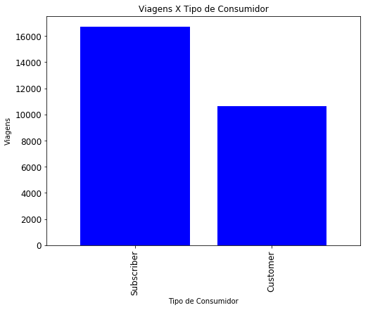

```python
# TODO: plote um gráfico de barras que mostre quantidade de viagens por subscription_type
# lembrando que quando o comando .plot é usado, se pode escolher o tipo de gráfico usando
# o parâmetro kind. Ex: plot(kind='bar')
import matplotlib.pyplot as plt
graph = (trip_data['subscription_type'].value_counts()).plot(kind='bar', figsize=(8,6), title ="Viagens X Tipo de Consumidor", fontsize=12, color='blue', width=0.8)
graph.set_xlabel("Tipo de Consumidor")
graph.set_ylabel("Viagens")
plt.show()
```

Para que você possa conferir se os seus gráficos estão corretos, usaremos a função `use_plot()`. O segundo argumento da função nos permite contar as viagens em uma variável selecionada, exibindo as informações em um gráfico. A expressão abaixo mostrará como deve ter ficado o seu gráfico acima.

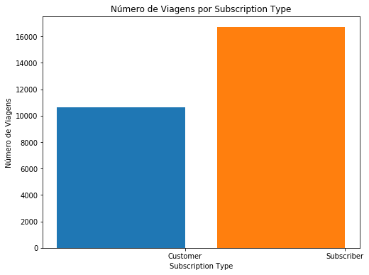

```python
# como o seu gráfico deve ficar. Descomente a linha abaixo caso queira rodar este comando
usage_plot(trip_data, 'subscription_type')
```

> *Nota*: Perceba que provavelmente o seu gráfico não ficou exatamente igual, principalmente pelo título e pelo nome dos eixos. Lembre-se, estes são detalhes mas fazem toda a diferença quando você for apresentar os gráficos que você analisou. Neste Nanodegree não focaremos nestas questões, mas tenha em mente que ter os gráficos acertados é de extrema importância.

Parece que existe 50% mais viagens feitas por assinantes (subscribers) no primeiro mês do que outro tipos de consumidores. Vamos tentar uma outra variável. Como é a distribuição da duração das viagens (trip duration)?

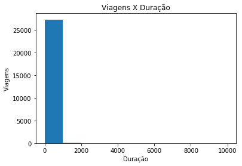

```python
# TODO: Faça um gráfico baseado nas durações

plt.hist(trip_data['duration'], bins=10)
plt.title('Viagens X Duração')
plt.xlabel('Duração')
plt.ylabel('Viagens')
plt.show()
```

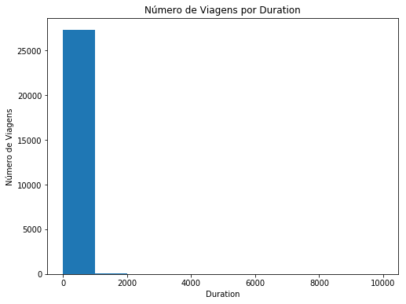

```python
# rode este comando abaixo caso esteja em dúvida quanto ao resultado esperado
usage_plot(trip_data, 'duration')
```

Parece muito estranho, não é? Dê uma olhada nos valores de duração no eixo x. A maioria dos passeios deve ser de 30 minutos ou menos, uma vez que há taxas de excesso de tempo extra em uma única viagem. A primeira barra abrange durações de até 1000 minutos, ou mais de 16 horas. Com base nas estatísticas que obtivemos do `use_stats()`, deveríamos ter esperado algumas viagens com durações muito longas que levem a média a ser muito superior à mediana: o gráfico mostra isso de forma dramática, mas inútil.

Ao explorar os dados, muitas vezes você precisará trabalhar com os parâmetros da função de visualização para facilitar a compreensão dos dados. É aqui que os filtros vão ajudar você. Comecemos por limitar as viagens de menos de 60 minutos.

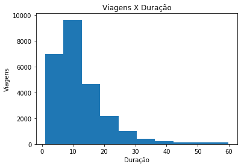

```python
# TODO: faça um gráfico de barras para os dados com duração inferior a 60 minutos.
plt.hist(((trip_data.loc[trip_data['duration'] < 60])['duration']), bins=10)
plt.title('Viagens X Duração')
plt.xlabel('Duração')
plt.ylabel('Viagens')
plt.show()
```

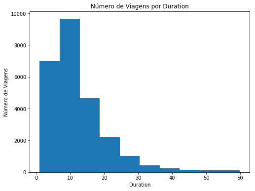

```python
# descomente a linha abaixo para verificar o gráfico esperado.
usage_plot(trip_data, 'duration', ['duration < 60'])
```

Isso está bem melhor! Você pode ver que a maioria das viagens têm menos de 30 minutos de duração, mas que você pode fazer mais para melhorar a apresentação. Uma vez que a duração mínima não é 0, a barra da esquerda está ligeiramente acima de 0. Nós queremos saber onde existe um limite perto dos 30 minutos, então ficará mais agradável se tivermos tamanhos de intervalos (bin sizes) e limites dos intervalos que correspondam a alguns minutos.

Felizmente, o Pandas e o Matplotlib te dão a opção de resolver ester problemas. Uma das maneiras de fazê-lo é definindo qual o intervalo no eixo x (parâmetro range) e quantos intervalos desejamos (bins).

No campo abaixo, faça o ajuste do gráfico para que os limites das barras se encontrem nas extremidades e que as barras tenham tamanho 5 (0, 5, 10, 15, etc). Se precisar, use a [documentação](http://matplotlib.org/api/_as_gen/matplotlib.axes.Axes.hist.html#matplotlib.axes.Axes.hist).

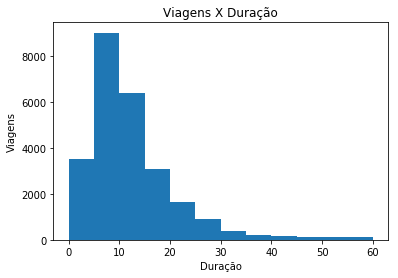

```python
# faça o gráfico ajustado que começará no 0 e terá o bin size de 5
plt.hist(((trip_data.loc[trip_data['duration'] < 60])['duration']), range=(0,60), bins=(60//5))
plt.title('Viagens X Duração')
plt.xlabel('Duração')
plt.ylabel('Viagens')
plt.show()
```

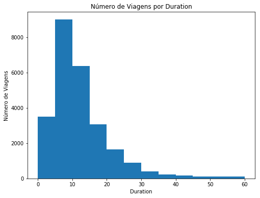

```python
# rode esta linha para verificar como deve ficar o seu gráfico
usage_plot(trip_data, 'duration', ['duration < 60'], boundary = 0, bin_width = 5)
```

Pequenos ajustes como este podem ser pequenos mas fazem toda a diferença na entrega de um trabalho de qualidade e com atenção aos detalhes.

# Pergunta 4

Analise o histograma do exercicio anterior e responda:

Qual o intervalo de duração com maior quantidade de viagens?

**Reposta**: O intervalo de duração com maior quantidade de viagens é entre 5 e 10 minutos.

# Pergunta 4.1

Com base na sua resposta da pergunta anterior, conte quantas viagens existem para cada origem e destino desse intervalo de tempo. Monte uma tabela que demonstre isso.

Qual origem e destino tem a maior quantidade de viagens? Aproximadamente quantas viagens foram feitas nesta faixa de tempo?

**Reposta**: De acordo com o que pesquisei não é permitido fazer a devolução da bicicleta em uma cidade diferente, por isso se analisarmos origem e destino com este dataframe em que substituímos as estações pela cidade o resultado já é obvio, será a cidade com maior número de usuários que é São Francisco. Por isso fiz a analise agrupando apenas por cidade e o resultado foi San Francisco com 8.110 bicicletas alugadas dentro do range de tempo de 5 e 10 minutos. Na dúvida eu fiz por estação também e o resultado foi que a origem e destino com o maior numero de viagens dentro deste range foi Harry Bridges Plaza (Ferry Building) até Embarcadero at Sansome com 102 viagens.

```python
#Fazendo o filtro de duração dentro do intervalo por cidade
trip_data_range = trip_data[(trip_data['duration'] >= 5) & (trip_data['duration'] < 10)]
trip_data_grouped_by_city = trip_data_range.groupby(['start_city']).size()
trip_data_grouped_by_city
```

```
start_city
Mountain View     105
Palo Alto          50
Redwood City       66
San Francisco    8110
San Jose          672
dtype: int64
```

```python
#Fazendo o filtro de duração dentro do intervalo por estação de inicio e de fim
data_with_station = pd.read_csv('201309_trip_data.csv')
data_with_station_range = data_with_station[(data_with_station.iloc[0:, 1] >= 300) & (data_with_station.iloc[0:, 1] < 600)]
data_with_station_range_grouped = data_with_station_range.groupby(['Start Station', 'End Station']).size()
data_with_station_range_grouped_sorted = data_with_station_range_grouped.sort_values(ascending=False)
data_with_station_range_grouped_sorted.head()
```

```
Start Station                         End Station
Harry Bridges Plaza (Ferry Building)  Embarcadero at Sansome                  102
Market at Sansome                     2nd at South Park                        96
Embarcadero at Sansome                Harry Bridges Plaza (Ferry Building)     87
Steuart at Market                     2nd at Townsend                          81
2nd at South Park                     Market at Sansome                        80
dtype: int64
```

## Fazendo suas Próprias Análises

Agora que você fez alguma exploração em uma pequena amostra do conjunto de dados, é hora de avançar e reunir todos os dados em um único arquivo e ver quais tendências você pode encontrar. O código abaixo usará a mesma função `summarise_data()` para processar dados. Depois de executar a célula abaixo, você terá processado todos os dados em um único arquivo de dados. Observe que a função não exibirá qualquer saída enquanto ele é executado, e isso pode demorar um pouco para ser concluído, pois você tem muito mais dados do que a amostra com a qual você trabalhou.

```python
station_data = ['201402_station_data.csv',
                '201408_station_data.csv',
                '201508_station_data.csv' ]
trip_in = ['201402_trip_data.csv',
           '201408_trip_data.csv',
           '201508_trip_data.csv' ]
trip_out = 'babs_y1_y2_summary.csv'

# Esta função irá ler as informações das estações e das viagens
# e escreverá um arquivo processado com o nome trip_out
summarise_data(trip_in, station_data, trip_out)
```

Já que a função `summarise_data()` escreveu um arquivo de saída, a célula acima não precisa ser rodada novamente mesmo que este notebook seja fechado e uma nova sessão seja criada. Você pode simplesmente ler os dados novamente e fazer a exploração deste ponto (não esqueça de executar a parte das funções no começo do notebook caso esteja em uma nova sessão)

```python
trip_data = pd.read_csv('babs_y1_y2_summary.csv')
display(trip_data.head())
```

|  | duration | start_date | start_year | start_month | start_hour | weekday | start_city | end_city | subscription_type |
| --- | --- | --- | --- | --- | --- | --- | --- | --- | --- |
| 0 | 1.050000 | 29/08/2013 | 2013 | 8 | 14 | 4 | San Francisco | San Francisco | Subscriber |
| 1 | 1.166667 | 29/08/2013 | 2013 | 8 | 14 | 4 | San Jose | San Jose | Subscriber |
| 2 | 1.183333 | 29/08/2013 | 2013 | 8 | 10 | 4 | Mountain View | Mountain View | Subscriber |
| 3 | 1.283333 | 29/08/2013 | 2013 | 8 | 11 | 4 | San Jose | San Jose | Subscriber |
| 4 | 1.383333 | 29/08/2013 | 2013 | 8 | 12 | 4 | San Francisco | San Francisco | Subscriber |

#### Agora é a SUA vez de fazer a exploração do dataset (do conjunto de dados) completo.

Aproveite para fazer filtros nos dados e tentar encontrar padrões nos dados.

Explore algumas variáveis diferentes usando o mesmo racional acima e tome nota de algumas tendências que você encontra. Sinta-se livre para criar células adicionais se quiser explorar o conjunto de dados de outras maneiras ou de várias maneiras.

> **Dica**: para adicionar células adicionais a um notebook, você pode usar as opções "Inserir célula acima" (Insert Cell Above) e "Insert Cell Below" na barra de menu acima. Há também um ícone na barra de ferramentas para adicionar novas células, com ícones adicionais para mover as células para cima e para baixo do documento. Por padrão, as novas células são do tipo de código; Você também pode especificar o tipo de célula (por exemplo, Código ou Markdown) das células selecionadas no menu Cell ou no menu dropdown na barra de ferramentas.

Um feito com suas explorações, copie as duas visualizações que você achou mais interessantes nas células abaixo e responda as seguintes perguntas com algumas frases descrevendo o que você encontrou e por que você selecionou os números. Certifique-se de que você ajusta o número de caixas ou os limites da bandeja para que efetivamente transmitam os resultados dos dados. Sinta-se livre para complementar isso com quaisquer números adicionais gerados a partir de `use_stats()` ou coloque visualizações múltiplas para suportar suas observações.

Para ver alguns outros tipos de gráficos que o matplotlib (padrão do Pandas) possui, leia [este artigo](https://www.labri.fr/perso/nrougier/teaching/matplotlib/#other-types-of-plots).

Para entender um pouco mais como e quais gráficos podem ser úteis, leia [este documento](https://www.tableau.com/sites/default/files/media/Whitepapers/which_chart_v6_ptb.pdf). Ele lhe dará um pouco de idéia de como mostrar os dados de forma mais acertada

# Pergunta 5a

Explore os dados e faça um gráfico que demonstre alguma particularidade dos dados:

# Iniciando a análise

Qual a relação do uso durante os meses do ano? Será que existe relação com a estação do ano?

Para reponder a minha primeira pergunta vou começar plotando um gráfico dos alugueis durante os meses do ano e o tipo de aluguel dentro de cada mês:

# Gráfico de alugueis por meses e tipo de aluguel

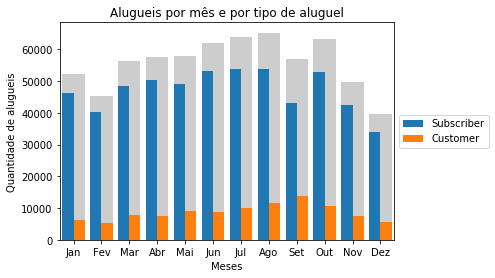

```python
# Gráfico final 1
# Gráfico de Alugueis por meses e tipo de aluguel
import seaborn as sns
ax = sns.countplot(x="start_month", data=trip_data, color='#CDCDCD')
ax = sns.countplot(x='start_month', hue='subscription_type', data=trip_data, saturation=1)
ax.set_title('Alugueis por mês e por tipo de aluguel')
ax.set_xlabel('Meses')
ax.set_ylabel('Quantidade de alugueis')
ax.legend(bbox_to_anchor=(1, 0.5), loc='center left')
months = ['Jan', 'Fev', 'Mar', 'Abr', 'Mai', 'Jun', 'Jul', 'Ago', 'Set', 'Out', 'Nov', 'Dez']
ax.set_xticklabels(months);
```

Como é possível visualizar no gráfico acima os meses de maior uso são os meses de verão. Podemos ver também que a grande maioria do número de alugueis são por subscribers e que a quantidade destes consumidores é um pouco mais bem distribuída. Os meses com menor uso por parte dos assinantes são (em ordem) os meses de dezembro, fevereiro e setembro. Já os meses com maior uso são os meses de junho, julho e agosto, quase empatados.

Os meses com maior uso por parte dos usuários esporádicos são (em ordem) os meses de setembro, agosto e julho. Já os meses com menor uso são os meses de dezembro, janeiro e fevereiro.

O mês de setembro é um dos meses com o menor uso por parte dos usuários que usam assinatura e é o mês com maior uso por parte dos usuários esporádicos. O mês de setembro é o final do verão e muitas pessoas tiram férias e aproveitam para viajar, por este motivo o uso dos usuários mais assíduos cai, pois muitos estão de férias e ou estão viajando ou não precisam usar tanto para a locomoção diária. Já os usuários esporádicos aumentam, pois se tratam de turistas ou de pessoas que moram na cidade e usam as bicicletas para lazer durante o verão.

Com isso acredito que seja possível afirmar que as pessoas que usam como subscriber, em sua maioria, são moradores das cidades que utilizam as bicicletas para locomoção diária como ir ao trabalho, escola e etc. Já os usuários esporádicos acredito que podemos afirmar que em sua maioria são turistas ou residentes que usam as bicicletas para lazer.

A relação com as estações do ano me deixou curioso, por isso vou fazer um gráfico fazendo a análise por estação do ano. Vou começar adicionando a coluna “season” ao dataframe para poder plotar este gráfico.

# Adicionando a coluna "season" ao DataFrame e plotando o gráfico

```python
# Adicionar estações do ano no DataFrame
trip_data['season'] = trip_data['start_month']
trip_data['season'].replace([1, 2, 3], 'Winter', inplace=True)
trip_data['season'].replace([4, 5, 6], 'Spring', inplace=True)
trip_data['season'].replace([7, 8, 9], 'Summer', inplace=True)
trip_data['season'].replace([10, 11, 12], 'Fall', inplace=True)
display(trip_data.head())
```

|  | duration | start_date | start_year | start_month | start_hour | weekday | start_city | end_city | subscription_type | season |
| --- | --- | --- | --- | --- | --- | --- | --- | --- | --- | --- |
| 0 | 1.050000 | 29/08/2013 | 2013 | 8 | 14 | 4 | San Francisco | San Francisco | Subscriber | Summer |
| 1 | 1.166667 | 29/08/2013 | 2013 | 8 | 14 | 4 | San Jose | San Jose | Subscriber | Summer |
| 2 | 1.183333 | 29/08/2013 | 2013 | 8 | 10 | 4 | Mountain View | Mountain View | Subscriber | Summer |
| 3 | 1.283333 | 29/08/2013 | 2013 | 8 | 11 | 4 | San Jose | San Jose | Subscriber | Summer |
| 4 | 1.383333 | 29/08/2013 | 2013 | 8 | 12 | 4 | San Francisco | San Francisco | Subscriber | Summer |

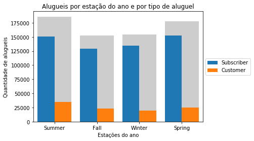

```python
# Gráfico de alugueis por estação do ano e tipo de aluguel
ax = sns.countplot(x="season", data=trip_data, color='#CDCDCD')
ax = sns.countplot(x='season', hue='subscription_type', data=trip_data, saturation=1)
ax.set_title('Alugueis por estação do ano e por tipo de aluguel')
ax.set_xlabel('Estações do ano')
ax.set_ylabel('Quantidade de alugueis')
ax.legend(bbox_to_anchor=(1, 0.5), loc='center left');
```

Neste novo gráfico podemos ver com mais clareza a relação da quantidade de alugueis com a estação do ano. Podemos ver claramente também que os alugueis por usuários esporádicos aumenta no verão. A estação com o maior numero total de usuários é o verão, seguido pela primavera que por sua vez fica acima do outono e inverno que estão muito próximos.

Acredito que o motivo pelo qual não temos uma queda muito grande no inverno é pelo fato de estarmos falando de cidades na Califórnia que é conhecida como “Sunny State”. Lá as temperaturas não ficam muito baixas nem na estação mais fria do ano. Porém de acordo com o ano calendário não é um mês de férias, isto por sua vez impacta mais na queda de usuários esporádicos do que de usuários que tem assinatura e que usam as bicicletas para locomoção diária.

Para tirar essa dúvida vou fazer mais um gráfico dos alugueis, só que desta vez por dia da semana.

# Gráfico de alugueis por dia da semana e tipo de aluguel

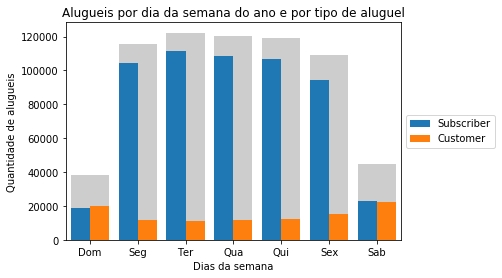

```python
# Gráfico de alugueis por dia da semana e tipo de aluguel
ax = sns.countplot(x="weekday", data=trip_data, color='#CDCDCD')
ax = sns.countplot(x='weekday', hue='subscription_type', data=trip_data, saturation=1)
ax.set_title('Alugueis por dia da semana do ano e por tipo de aluguel')
ax.set_xlabel('Dias da semana')
ax.set_ylabel('Quantidade de alugueis')
ax.legend(bbox_to_anchor=(1, 0.5), loc='center left')
days = ['Dom', 'Seg', 'Ter', 'Qua', 'Qui', 'Sex', 'Sab']
ax.set_xticklabels(days);
```

Neste novo gráfico podemos ver que os alugueis por usuários por assinatura é muito maior durante os dias de semana, enquanto nesses dias o uso por parte dos usuários esporádicos é muito pequeno. Já nos finais de semana a quantidade de alugueis destes dois grupos se iguala, pois os usuários por assinatura tem uma queda muito grande e os usuários esporádicos tem um aumento visível.

Com isso podemos concluir definitivamente que os usuários por assinatura são pessoas que utilizam as bicicletas para locomoção diária e os usuários esporádicos são turistas ou residentes que usam as bicicletas para lazer.

Como ainda estou curioso vou explorar os dados mais um pouco de forma quantitativa! Vou começar tirando a média de uso dos tipos de usuários.

```python
# Separando o DataFrame por tipo de usuário
subscribers = trip_data[(trip_data['subscription_type'] == 'Subscriber')]
customers = trip_data[(trip_data['subscription_type'] == 'Customer')]

display(subscribers.head())
display(customers.head())
```

|  | duration | start_date | start_year | start_month | start_hour | weekday | start_city | end_city | subscription_type | season |
| --- | --- | --- | --- | --- | --- | --- | --- | --- | --- | --- |
| 0 | 1.050000 | 29/08/2013 | 2013 | 8 | 14 | 4 | San Francisco | San Francisco | Subscriber | Summer |
| 1 | 1.166667 | 29/08/2013 | 2013 | 8 | 14 | 4 | San Jose | San Jose | Subscriber | Summer |
| 2 | 1.183333 | 29/08/2013 | 2013 | 8 | 10 | 4 | Mountain View | Mountain View | Subscriber | Summer |
| 3 | 1.283333 | 29/08/2013 | 2013 | 8 | 11 | 4 | San Jose | San Jose | Subscriber | Summer |
| 4 | 1.383333 | 29/08/2013 | 2013 | 8 | 12 | 4 | San Francisco | San Francisco | Subscriber | Summer |

|  | duration | start_date | start_year | start_month | start_hour | weekday | start_city | end_city | subscription_type | season |
| --- | --- | --- | --- | --- | --- | --- | --- | --- | --- | --- |
| 24 | 2.683333 | 29/08/2013 | 2013 | 8 | 10 | 4 | San Francisco | San Francisco | Customer | Summer |
| 30 | 2.883333 | 29/08/2013 | 2013 | 8 | 11 | 4 | San Francisco | San Francisco | Customer | Summer |
| 41 | 3.133333 | 29/08/2013 | 2013 | 8 | 19 | 4 | San Francisco | San Francisco | Customer | Summer |
| 48 | 3.483333 | 29/08/2013 | 2013 | 8 | 17 | 4 | San Francisco | San Francisco | Customer | Summer |
| 51 | 3.566667 | 29/08/2013 | 2013 | 8 | 17 | 4 | San Francisco | San Francisco | Customer | Summer |

```python
# Extraindo os valores
total_mean = trip_data['duration'].mean()
print ('Média de tempo por viagem total: %.2f' %total_mean)

subscribers_mean = subscribers['duration'].mean()
print ('Média de tempo por viagem Subscriber: %.2f' %subscribers_mean)

customers_mean = customers['duration'].mean()
print ('Média de tempo por viagem Customer: %.2f' %customers_mean)

diff = (customers_mean - subscribers_mean)*100
print ('As viagens do tipo Customer duram em média {0:.2f}% mais do que as viagens do tipo Subscriber'.format(diff))
```

[output not shown]

Para fazer a locação você tem 3 opções são elas:

Assinatura: por $149,00 anuais você tem viagens ilimitadas de 30 minutos por 1 ano.

Passes diários: por $9,95 (24 horas) ou $19,95(72 horas) você tem viagens ilimitadas de 30 minutos pelo período escolhido.

Viagem única: por $3,00 você tem direito a uma viagem de 30 minutos.

Todos os planos tem uma cobrança extra de $3,00 por a cada 15 minutos extras quando a viagem ultrapassa 30 minutos.

Vamos fazer mais algumas contas!

```python
# Mais alguns valores interessantes
min_trips_subs = 149/3
print ('Minimo de viagens necessária no ano para valer a pena uma assiantura: %.0f' %min_trips_subs)

customer_paid_extra = ((customers_mean-30)/15)*3
print ('Customers pagam em média $%.2f extra por viagem' %customer_paid_extra)

customers_over_30 = ((customers.loc[customers['duration'] > 30])['duration']).count()
customers_total = customers['duration'].count()
proportion_customers = (customers_over_30/customers_total)*100
print ('Customers que usam acima dos 30 minutos são %d' %customers_over_30)
print ('Estes customers que usam acima dos 30 minutos são {0:.2f}%'.format(proportion_customers))

subscribers_over_30 = number = ((subscribers.loc[subscribers['duration'] > 30])['duration']).count()
subscribers_total = subscribers['duration'].count()
proportion_subscribers = (subscribers_over_30/subscribers_total)*100
print ('Subscribers que usam acima dos 30 minutos são %d' %subscribers_over_30)
print ('Estes subscribers que usam acima dos 30 minutos são {0:.2f}%'.format(proportion_subscribers))
```

```
Minimo de viagens necessária no ano para valer a pena uma assiantura: 50
Customers pagam em média $7.17 extra por viagem
Customers que usam acima dos 30 minutos são 31267
Estes customers que usam acima dos 30 minutos são 30.29%
Subscribers que usam acima dos 30 minutos são 3808
Estes subscribers que usam acima dos 30 minutos são 0.67%
```

Veja que para valer a pena ser um assinante você precisa fazer no mínimo 50 viagens por ano, sendo viagens de menos de 30 minutos. Por isso a média do tempo gasto em cada viagem por assinantes é menor, cerca de 9,83 minutos. Como eles usam como locomoção diária vale muito a pena pagar os $149 anuais e usar a vontade dentro do tempo de viagem de 30 minutos e não é necessário mais do que isso, pois eles usam para atividades do dia a dia como ir para o trabalho, escola e etc. Veja que apenas 0,67% dos alugueis por assinatura ultrapassam os 30 minutos. Isto porque para os assinantes que utilizam as bicicletas para locomoção diária não vale a pena pagar extra pelo uso.

Já os usuários esporádicos pagam em média $7,17 extra por locação, sendo que 30,29% dos alugueis deste tipo ultrapassam os 30 minutos. Isto acontece pois eles não estão preocupados com a economia que usar a bicicleta para locomoção diária pode trazer, eles estão em busca de lazer e por ser esporádico não se preocupam em pagar um pouco mais.

Para finalizar vou plotar o histograma de duração por viagem para cada grupo.

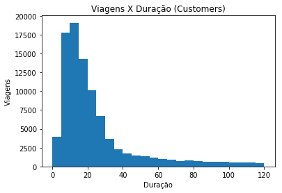

```python
plt.hist(((customers.loc[customers['duration'] <= 120])['duration']), range=(0,120), bins=(120//5))
plt.title('Viagens X Duração (Customers)')
plt.xlabel('Duração')
plt.ylabel('Viagens')
plt.show()
```

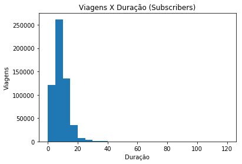

```python
plt.hist(((subscribers.loc[subscribers['duration'] <= 120])['duration']), range=(0,120), bins=(120//5))
plt.title('Viagens X Duração (Subscribers)')
plt.xlabel('Duração')
plt.ylabel('Viagens')
plt.show()
```

Nos dois histogramas podemos ver que a maior concentração de viagens está praticamente dentro do mesmo intervalo nos dois casos. Porém no caso dos usuários esporádicos a distribuição é muito mais ampla, chegando a ter viagens de até 120 minutos, enquanto entre os usuários por assinatura a maioria absoluta é de menos de 20 minutos.

O que é interessante na visualização acima? Por que você a selecionou?

**Answer**: Eu escolhi essa visualização porque queria ver como se comportava o uso das bicicletas no decorrer do ano, queria ver se era sazonal.

Pude chegar à conclusão de que sim, o uso varia de acordo com a estação do ano e os dias da semana. Também pude concluir que existem diferenças entre os dois grupos de pessoas que utilizam o serviço, de um lado temos os assinantes que usam como locomoção diária para ir ao trabalho, escola e etc. Já do outros lados temos os usuários esporádicos, que usam para lazer, neste grupo considero 2 perfis diferentes: turistas, e moradores que não usam como locomoção diária mas gostas de usar a bicicleta como lazer.

# Pergunta 5b

Faça um gráfico que demonstre alguma particularidade dos dados:

Existe alguma relação com o clima e a quantidade de alugueis?

Para responder esta pergunta eu vou começar fazendo a junção dos 3 arquivos de clima disponibilizados. Para isso eu vou fazer uma função chamada summarize_weather. Esta função pega os 3 arquivos de clima e cria um novo pegando apenas as colunas que dizem respeito a temperatura média, umidade relativa do ar média, velocidade média do vento, precipitação e código postal. Vou aproveitar e trocar o código postal pelo nome da cidade. Também vou arrumar o campo data, pois mais na frente vou precisar dele no formato dd/mm/aaaa para fazer o merge com o dataframe trip_data.

```python
# Função que irá criar o novo arquivo com informações do clima
# Alguns campos estão com "espaço", isso foi proposital, uma vez que no arquivo csv eles também estão
def summarize_weather(weather_data, file_out):
    # Cria um novo arquivo onde serão escritas as informações extraidas
    with open(file_out, 'w') as f_out:
        # Colunas que desejo no novo arquivo
        out_colnames = ['Date', 'Temperature', 'Humidity', 'Wind_Speed', 'Preciptation', 'City']
        weather_writer = csv.DictWriter(f_out, fieldnames = out_colnames)
        weather_writer.writeheader()


        for data_file in weather_data:
            with open(data_file, 'r') as f_in:
                weather_reader = csv.DictReader(f_in)

                for row in weather_reader:
                    new_point = {}
                # Em um dos arquivos a coluna de data está como Date, já nos outros 2 está como PDT, por isso o primeiro if
                    if 'Date' in row:
                        new_date = datetime.strptime(row['Date'], '%m/%d/%Y')
                        # Converte a data para o mesmo formato do trip_data
                        new_point['Date'] = new_date.strftime('%d/%m/%Y')
                        new_point['Temperature'] = row['Mean_Temperature_F']
                        new_point['Humidity'] = row['Mean_Humidity ']
                        new_point['Wind_Speed'] = row['Mean_Wind_Speed_MPH ']
                        # Alguns dias em que a precipiação foi menor do que 0,1 estão com T, este if troca para 0
                        if row['Precipitation_In '] == 'T':
                            new_point['Preciptation'] = 0
                        else:
                            new_point['Preciptation'] = row['Precipitation_In ']
                        # Este if troca o código postal pela Cidade
                        if int(row['zip']) == 94041:
                            new_point['City'] = 'Mountain View'
                        elif int(row['zip']) == 94063:
                            new_point['City'] = 'Redwood City'
                        elif int(row['zip']) == 94107:
                            new_point['City'] = 'San Francisco'
                        elif int(row['zip']) == 94301:
                            new_point['City'] = 'Palo Alto'
                        elif int(row['zip']) == 95113:
                            new_point['City'] = 'San Jose'

                    else:
                        new_date = datetime.strptime(row['PDT'], '%m/%d/%Y')
                        # Converte a data para o mesmo formato do trip_data
                        new_point['Date'] = new_date.strftime('%d/%m/%Y')
                        new_point['Temperature'] = row['Mean TemperatureF']
                        new_point['Humidity'] = row[' Mean Humidity']
                        new_point['Wind_Speed'] = row[' Mean Wind SpeedMPH']
                        # Alguns dias em que a precipiação foi menor do que 0,1 estão com T, este if troca para 0
                        if row['PrecipitationIn'] == 'T':
                            new_point['Preciptation'] = 0
                        else:
                            new_point['Preciptation'] = row['PrecipitationIn']
                        # Este if troca o código postal pela Cidade
                        if int(row['Zip']) == 94041:
                            new_point['City'] = 'Mountain View'
                        elif int(row['Zip']) == 94063:
                            new_point['City'] = 'Redwood City'
                        elif int(row['Zip']) == 94107:
                            new_point['City'] = 'San Francisco'
                        elif int(row['Zip']) == 94301:
                            new_point['City'] = 'Palo Alto'
                        elif int(row['Zip']) == 95113:
                            new_point['City'] = 'San Jose'

                    weather_writer.writerow(new_point)
```

```python
# Cria uma variável com o nome dos 3 arquivos
weather_data = ['201402_weather_data.csv', '201408_weather_data.csv', '201508_weather_data.csv']
file_out = 'weather_summary.csv'

# Chama a função para criar o novo arquivo
summarize_weather(weather_data, file_out)

# Cria um novo dataframe a partir do novo arquivo e mostra os primeiros 5 registros
weather_data = pd.read_csv('weather_summary.csv')
display(weather_data.head())
```

|  | Date | Temperature | Humidity | Wind_Speed | Preciptation | City |
| --- | --- | --- | --- | --- | --- | --- |
| 0 | 29/08/2013 | 68.0 | 75.0 | 11.0 | 0.0 | San Francisco |
| 1 | 30/08/2013 | 69.0 | 70.0 | 13.0 | 0.0 | San Francisco |
| 2 | 31/08/2013 | 64.0 | 75.0 | 15.0 | 0.0 | San Francisco |
| 3 | 01/09/2013 | 66.0 | 68.0 | 13.0 | 0.0 | San Francisco |
| 4 | 02/09/2013 | 69.0 | 77.0 | 12.0 | 0.0 | San Francisco |

Agora é impotante verificar se existem valores faltando no dataframe.

```python
#Verificando se existem valores faltando no dataframe
weather_data.isnull().sum()
```

```
Date             0
Temperature      4
Humidity        54
Wind_Speed       1
Preciptation     1
City             0
dtype: int64
```

Pudemos verificar que existem alguns valores faltando no dataframe, apesar de ser muito poucos vou limpar estes dados para que eles não Influenciem em análises futuras.

```python
# No campo temperatura os valores que faltam serão substituidos pela média da coluna
temp_mean = weather_data['Temperature'].mean()
weather_data['Temperature'].fillna(temp_mean, inplace=True)

# No campo umidade os valores que faltam serão substituidos pela média da coluna
humidity_mean = weather_data['Humidity'].mean()
weather_data['Humidity'].fillna(temp_mean, inplace=True)

# No campo valocidade do vento os valores que faltam serão substituidos pela média da coluna
wind_mean = weather_data['Wind_Speed'].mean()
weather_data['Wind_Speed'].fillna(wind_mean, inplace=True)

# No campo precipitação os valores que faltam vão receber o valor 0
weather_data['Preciptation'].fillna(0, inplace=True)

# Verifica se não existem mais valores faltantes
weather_data.isnull().sum()
```

```
Date            0
Temperature     0
Humidity        0
Wind_Speed      0
Preciptation    0
City            0
dtype: int64
```

Pronto! Agora que o problema dos valores que faltavam foram resolvidos eu vou fazer a junção dos dois dataframes, dessa forma eu vou passar a ter as condições climaticas em cada aluguel.

```python
# Faz o merge entre os dois dataframes
# Como existe um registro diario para cada cidade é preciso usar a chave data e cidade para fazer o merge
trip_data_weather = trip_data.merge(weather_data, left_on=['start_date', 'start_city'], right_on=['Date', 'City'], how='left' )

# Mostra os primeiros 5 registro dos dataframes unidos
display(trip_data_weather.head())
```

|  | duration | start_date | start_year | start_month | start_hour | weekday | start_city | end_city | subscription_type | season | Date | Temperature | Humidity | Wind_Speed | Preciptation | City |
| --- | --- | --- | --- | --- | --- | --- | --- | --- | --- | --- | --- | --- | --- | --- | --- | --- |
| 0 | 1.050000 | 29/08/2013 | 2013 | 8 | 14 | 4 | San Francisco | San Francisco | Subscriber | Summer | 29/08/2013 | 68.0 | 75.0 | 11.0 | 0.0 | San Francisco |
| 1 | 1.166667 | 29/08/2013 | 2013 | 8 | 14 | 4 | San Jose | San Jose | Subscriber | Summer | 29/08/2013 | 72.0 | 69.0 | 7.0 | 0.0 | San Jose |
| 2 | 1.183333 | 29/08/2013 | 2013 | 8 | 10 | 4 | Mountain View | Mountain View | Subscriber | Summer | 29/08/2013 | 70.0 | 72.0 | 5.0 | 0.0 | Mountain View |
| 3 | 1.283333 | 29/08/2013 | 2013 | 8 | 11 | 4 | San Jose | San Jose | Subscriber | Summer | 29/08/2013 | 72.0 | 69.0 | 7.0 | 0.0 | San Jose |
| 4 | 1.383333 | 29/08/2013 | 2013 | 8 | 12 | 4 | San Francisco | San Francisco | Subscriber | Summer | 29/08/2013 | 68.0 | 75.0 | 11.0 | 0.0 | San Francisco |

# Histograma Alugueis X Precipitação

Agora podemos fazer a análise dos alugueis de acordo com as condições climaticas. Vou começar fazendo um histograma de como se comporta a os alugueis de acordo com a chuva.

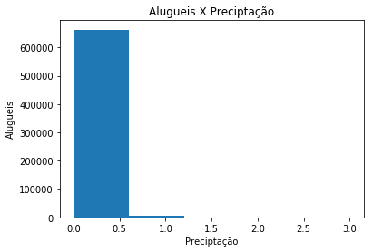

```python
# Plotando histograma da alugueis X preciptação
plt.hist(trip_data_weather['Preciptation'], range=(0, 3), bins=5)
plt.title('Alugueis X Preciptação')
plt.xlabel('Preciptação')
plt.ylabel('Alugueis')
plt.show()
```

Veja que interessante, a chuva é tão impactante nos alugueis que nem foi possível formar um histograma. Vamos analisar um pouco mais isso para ver o que aconteceu. Vou fazer uma tabela para ver como é o uso de acordo com a quantidade de precipitação.

```python
# Agrupando por preciptação e por quantidade
trip_preciptation = trip_data_weather.groupby('Preciptation').size()
display(trip_preciptation.head())

# % dos alugueis sem chuva
trip_without_preciptation = (trip_preciptation[0]/trip_preciptation.sum()) * 100
print ('A porcentagem de alugueis quando não tem chuva é %.2f' %trip_without_preciptation + '% do total de alugueis')
```

```
Preciptation
0.00    616547
0.01     16774
0.02      3332
0.03       782
0.04       247
dtype: int64
```

```
A porcentagem de alugueis quando não tem chuva é 92.03% do total de alugueis
```

Do total de alugueis 92% são feitos quando não chove nada no dia. Sobrando apenas 8% dos alugueis para os dias com chuva. Isso mostra claramente que a chuva é um fator de grande impacto nos alugueis, pois uma parte muito pequena dos alugueis acontecem em dias chuvosos.

Vamos ver como os alugueis se comportam em relação aos outros fatores climáticos.

# Histograma Alugueis X Temperatura

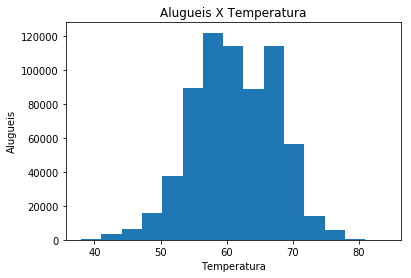

```python
# Plotando historama de alugueis X temperatura
plt.hist(trip_data_weather['Temperature'], range=(38, 84), bins=15)
plt.title('Alugueis X Temperatura')
plt.xlabel('Temperatura')
plt.ylabel('Alugueis')
plt.show()
```

Veja que interessante é a distribuição dos alugueis de acordo com a temperatura. Ninguém quer andar de bicicleta no frio, não é? Ao mesmo tempo andar de bicicleta com aquele sol rachando na cabeça é ruim, né? Por isso vemos que a maior concentração de alugueis está no meio, onde a temperatura é mais amena.

# Histograma Alugueis X Umidade

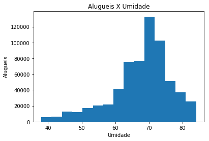

```python
# Plotando historama de alugueis X umidade
plt.hist(trip_data_weather['Humidity'], range=(38, 84), bins=15)
plt.title('Alugueis X Umidade')
plt.xlabel('Umidade')
plt.ylabel('Alugueis')
plt.show()
```

Com a umidade relativa do ar não é diferente, veja o comportamento do número de alugueis com o nível de umidade. Parece que as condições climáticas estão interferindo mais do que as estações do ano. Temos que lembrar que por se tratar da Califórnia as condições climáticas, principalmente a temperatura, não são tão afetadas pelas estações do ano, por isso a condição climática por si só tem um impacto maior.

# Histograma Alugueis X Velocidade do Vento

Vamos ver em relação ao vento agora.

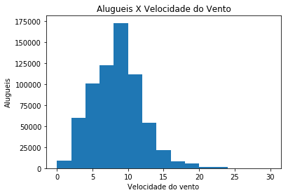

```python
# Plotando historama de alugueis X velocidade do vento
plt.hist(trip_data_weather['Wind_Speed'], range=(0, 30), bins=15)
plt.title('Alugueis X Velocidade do Vento')
plt.xlabel('Velocidade do vento')
plt.ylabel('Alugueis')
plt.show()
```

Eu vou plotar um gráfico destes fatores juntos para ficar mais fácil de ver a diferença. Porém como esses fatores tem valores em grandezas diferentes eu vou começar fazendo o feature scaling para ficar mais fácil de analisar. Depois vou criar um histograma com todos os dados juntos.

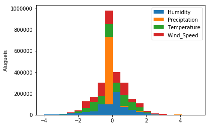

```python
# Feature Scaling
# Começar pegando apenas os dados de fatores climaticos
trip_data_weather_separeted = trip_data_weather[['Temperature', 'Humidity', 'Wind_Speed', 'Preciptation']].copy()

# Aplicar o Feature Scaling
from sklearn.preprocessing import StandardScaler
sc_X = StandardScaler()
auxdf = sc_X.fit_transform(trip_data_weather_separeted)

df2 = pd.DataFrame({'Temperature':auxdf[:,0],'Humidity':auxdf[:,1],'Wind_Speed':auxdf[:,2], 'Preciptation':auxdf[:,3]})
graph = df2.plot.hist(stacked=True, bins=20, range=(-4, 5));
graph.set_ylabel("Alugueis");
```

Como a precipitação é muito uma variável muito forte ela deixa o gráfico um pouco estranho. Por este motivo vou retirar ela para tentar montar o gráfico novamente.

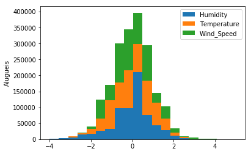

```python
# Gráfico sem precipitação
df2 = pd.DataFrame({'Temperature':auxdf[:,0],'Humidity':auxdf[:,1],'Wind_Speed':auxdf[:,2]})
graph = df2.plot.hist(stacked=True, bins=20, range=(-4, 5));
graph.set_ylabel("Alugueis");
```

Veja como os fatores climáticos impactam de maneira parecida nos alugueis de bicicletas. Isso na verdade já era esperado, pois é obvio que os fatores climáticos impactam em qualquer coisa que seja ao livre e que principalmente você não está protegido deles. Mas na verdade eu não acredito que seja os fatores climáticos individualmente que causem um impacto nos alugueis. Como sabemos os fatores climáticos estão ligados, pense que quando chove, a temperatura cai, o vento aumente e a umidade aumenta, e todos esses fatores mostraram que juntos levam ao mesmo resultado: a queda de alugueis. Se analisarmos esses dados ainda mais a fundo veremos que é a combinação de fatores climáticos que impactam nos alugueis e não cada um de forma isolada.

O que é interessante na visualização acima? Por que você a selecionou?

**Answer**: Eu queria ver se os fatores climaticos impactavam na quantidade de alugueis. Pude concluir que sim, eles impactam, porém não de forma individual, mas sim em conjunto.

## Conclusões

Parabéns pela conclusão do projeto! Esta é apenas uma amostragem do processo de análise de dados: gerando perguntas, limpando e explorando os dados. Normalmente, neste momento no processo de análise de dados, você pode querer tirar conclusões realizando um teste estatístico ou ajustando os dados a um modelo para fazer previsões. Há também muitas análises potenciais que podem ser realizadas se evoluirmos o código fornecido. Em vez de apenas olhar para o número de viagens no eixo de resultados, você pode ver quais recursos afetam coisas como a duração da viagem. Nós também não analisamos como os dados meteorológicos se encaixam no uso de bicicletas.

> **Dica**: se quisermos compartilhar os resultados de nossa análise com os outros, existe uma outra opção que não é enviar o arquivo jupyter Notebook (.ipynb). Também podemos exportar a saída do Notebook de uma forma que pode ser aberto mesmo para aqueles sem o Python instalado. No menu **File** na parte superior esquerda, vá para o submenu **Download as**. Você pode então escolher um formato diferente que pode ser visto de forma mais geral, como HTML (.html) ou PDF (.pdf). Você pode precisar de pacotes adicionais ou software para executar essas exportações.